# Capstone 1

Samsinar Ilyas

2021-03-31

# 1. Explanation about the data

The data is related with direct marketing campaigns of a Portuguese banking institution. The marketing campaigns were based on phone calls. Often, more than one contact to the same client was required, in order to access if the product (bank term deposit) would be (‘yes’) or not (‘no’) subscribed.

# 2. Input Data

Make sure the data is in the same path directory with R project

```r
bank <- read.csv("bank-full.csv", sep = ";")
```

## 2.1 Data Inspection

```r
head(bank)
```

```
##   age          job marital education default balance housing loan contact day
## 1  58   management married  tertiary      no    2143     yes   no unknown   5
## 2  44   technician  single secondary      no      29     yes   no unknown   5
## 3  33 entrepreneur married secondary      no       2     yes  yes unknown   5
## 4  47  blue-collar married   unknown      no    1506     yes   no unknown   5
## 5  33      unknown  single   unknown      no       1      no   no unknown   5
## 6  35   management married  tertiary      no     231     yes   no unknown   5
##   month duration campaign pdays previous poutcome  y
## 1   may      261        1    -1        0  unknown no
## 2   may      151        1    -1        0  unknown no
## 3   may       76        1    -1        0  unknown no
## 4   may       92        1    -1        0  unknown no
## 5   may      198        1    -1        0  unknown no
## 6   may      139        1    -1        0  unknown no
```

```r
tail(bank)
```

```
##       age          job  marital education default balance housing loan
## 45206  25   technician   single secondary      no     505      no  yes
## 45207  51   technician  married  tertiary      no     825      no   no
## 45208  71      retired divorced   primary      no    1729      no   no
## 45209  72      retired  married secondary      no    5715      no   no
## 45210  57  blue-collar  married secondary      no     668      no   no
## 45211  37 entrepreneur  married secondary      no    2971      no   no
##         contact day month duration campaign pdays previous poutcome   y
## 45206  cellular  17   nov      386        2    -1        0  unknown yes
## 45207  cellular  17   nov      977        3    -1        0  unknown yes
## 45208  cellular  17   nov      456        2    -1        0  unknown yes
## 45209  cellular  17   nov     1127        5   184        3  success yes
## 45210 telephone  17   nov      508        4    -1        0  unknown  no
## 45211  cellular  17   nov      361        2   188       11    other  no
```

```r
dim(bank)
```

```
## [1] 45211    17
```

```r
colnames(bank)
```

```
##  [1] "age"       "job"       "marital"   "education" "default"   "balance"
##  [7] "housing"   "loan"      "contact"   "day"       "month"     "duration"
## [13] "campaign"  "pdays"     "previous"  "poutcome"  "y"
```

From our inspection we can conclude : * banks data contain 45211 of rows and 17 of coloumns * Each of column name : “age”,“job”,“marital”,“education”,“default”,“balance”, “housing”,“loan”,“contact”,“day”,“month”,“duration”,“campaign”,“pdays”,“previous”,“poutcome”,“y”

## 2.2. Cleansing Data & Corrections

Check for missing value

```r
anyNA(bank)
```

```
## [1] FALSE
```

**Yeay, Nothing Missing Value!!**

Change the data type that is not appropriate

```r
name <- c(2:4, 9, 11, 16, 5, 7, 8, 17)
bank[ , name] <- lapply(bank[ , name] , factor)
str(bank)
```

```
## 'data.frame':    45211 obs. of  17 variables:
##  $ age      : int  58 44 33 47 33 35 28 42 58 43 ...
##  $ job      : Factor w/ 12 levels "admin.","blue-collar",..: 5 10 3 2 12 5 5 3 6 10 ...
##  $ marital  : Factor w/ 3 levels "divorced","married",..: 2 3 2 2 3 2 3 1 2 3 ...
##  $ education: Factor w/ 4 levels "primary","secondary",..: 3 2 2 4 4 3 3 3 1 2 ...
##  $ default  : Factor w/ 2 levels "no","yes": 1 1 1 1 1 1 1 2 1 1 ...
##  $ balance  : int  2143 29 2 1506 1 231 447 2 121 593 ...
##  $ housing  : Factor w/ 2 levels "no","yes": 2 2 2 2 1 2 2 2 2 2 ...
##  $ loan     : Factor w/ 2 levels "no","yes": 1 1 2 1 1 1 2 1 1 1 ...
##  $ contact  : Factor w/ 3 levels "cellular","telephone",..: 3 3 3 3 3 3 3 3 3 3 ...
##  $ day      : int  5 5 5 5 5 5 5 5 5 5 ...
##  $ month    : Factor w/ 12 levels "apr","aug","dec",..: 9 9 9 9 9 9 9 9 9 9 ...
##  $ duration : int  261 151 76 92 198 139 217 380 50 55 ...
##  $ campaign : int  1 1 1 1 1 1 1 1 1 1 ...
##  $ pdays    : int  -1 -1 -1 -1 -1 -1 -1 -1 -1 -1 ...
##  $ previous : int  0 0 0 0 0 0 0 0 0 0 ...
##  $ poutcome : Factor w/ 4 levels "failure","other",..: 4 4 4 4 4 4 4 4 4 4 ...
##  $ y        : Factor w/ 2 levels "no","yes": 1 1 1 1 1 1 1 1 1 1 ...
```

There is no missing value and the type of data is appropriate.

The data is ready to analysis!

# 3. Exploratory data analysis

View summary data

```r
summary(bank)
```

```
##       age                 job           marital          education
##  Min.   :18.00   blue-collar:9732   divorced: 5207   primary  : 6851
##  1st Qu.:33.00   management :9458   married :27214   secondary:23202
##  Median :39.00   technician :7597   single  :12790   tertiary :13301
##  Mean   :40.94   admin.     :5171                    unknown  : 1857
##  3rd Qu.:48.00   services   :4154
##  Max.   :95.00   retired    :2264
##                  (Other)    :6835
##  default        balance       housing      loan            contact
##  no :44396   Min.   : -8019   no :20081   no :37967   cellular :29285
##  yes:  815   1st Qu.:    72   yes:25130   yes: 7244   telephone: 2906
##              Median :   448                           unknown  :13020
##              Mean   :  1362
##              3rd Qu.:  1428
##              Max.   :102127
##
##       day            month          duration         campaign
##  Min.   : 1.00   may    :13766   Min.   :   0.0   Min.   : 1.000
##  1st Qu.: 8.00   jul    : 6895   1st Qu.: 103.0   1st Qu.: 1.000
##  Median :16.00   aug    : 6247   Median : 180.0   Median : 2.000
##  Mean   :15.81   jun    : 5341   Mean   : 258.2   Mean   : 2.764
##  3rd Qu.:21.00   nov    : 3970   3rd Qu.: 319.0   3rd Qu.: 3.000
##  Max.   :31.00   apr    : 2932   Max.   :4918.0   Max.   :63.000
##                  (Other): 6060
##      pdays          previous           poutcome       y
##  Min.   : -1.0   Min.   :  0.0000   failure: 4901   no :39922
##  1st Qu.: -1.0   1st Qu.:  0.0000   other  : 1840   yes: 5289
##  Median : -1.0   Median :  0.0000   success: 1511
##  Mean   : 40.2   Mean   :  0.5803   unknown:36959
##  3rd Qu.: -1.0   3rd Qu.:  0.0000
##  Max.   :871.0   Max.   :275.0000
##
```

**Let’s do the next analysis!**

*1. How many clients subscribed to term deposits and the number of clients who did not subscribe to term deposits in this campaign?*

Let’s use method table() to defined count of each category!

```r
table(bank$y)
```

```
##
##    no   yes
## 39922  5289
```

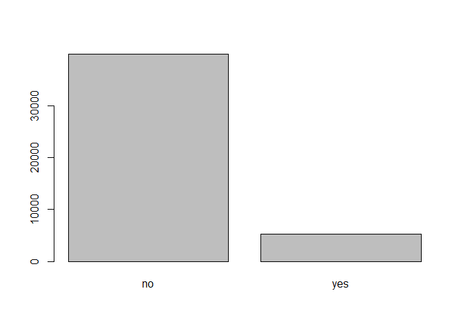

```r
barplot(table(bank$y))
```

*2. By age, from which category do most of the clients owned by the bank come from?*

Because the dataset does not divide age by category, it is necessary to divide the age by category first.

Create a copy of bank data

```r
newdata <- bank
head(newdata)
```

```
##   age          job marital education default balance housing loan contact day
## 1  58   management married  tertiary      no    2143     yes   no unknown   5
## 2  44   technician  single secondary      no      29     yes   no unknown   5
## 3  33 entrepreneur married secondary      no       2     yes  yes unknown   5
## 4  47  blue-collar married   unknown      no    1506     yes   no unknown   5
## 5  33      unknown  single   unknown      no       1      no   no unknown   5
## 6  35   management married  tertiary      no     231     yes   no unknown   5
##   month duration campaign pdays previous poutcome  y
## 1   may      261        1    -1        0  unknown no
## 2   may      151        1    -1        0  unknown no
## 3   may       76        1    -1        0  unknown no
## 4   may       92        1    -1        0  unknown no
## 5   may      198        1    -1        0  unknown no
## 6   may      139        1    -1        0  unknown no
```

Let’s see range of age

```r
newdata$age <- as.integer(newdata$age)
summary(newdata$age)
```

```
##    Min. 1st Qu.  Median    Mean 3rd Qu.    Max.
##   18.00   33.00   39.00   40.94   48.00   95.00
```

Create an age category, which is contains of:

- Older Adults (45-65)
- Adults (26-45)
- Teens (18-25)
- Aged (65-80)
- 80 and over

Create an age category and assign to object newdata

```r
newdata$age_category <- sapply(newdata$age, FUN = function(x){
   if(x <= 25){
      "Teens"
   }else if(x > 25 & x <= 45){
      "Adults"
   }else if(x > 45 & x <= 65){
     "Older Adults"
   } else if (x > 65 & x <= 80){
     "Aged"
   }else{
      "80 and over"
   }
})

newdata$age_category <- as.factor(newdata$age_category)
head(newdata, 10)
```

```
##    age          job  marital education default balance housing loan contact day
## 1   58   management  married  tertiary      no    2143     yes   no unknown   5
## 2   44   technician   single secondary      no      29     yes   no unknown   5
## 3   33 entrepreneur  married secondary      no       2     yes  yes unknown   5
## 4   47  blue-collar  married   unknown      no    1506     yes   no unknown   5
## 5   33      unknown   single   unknown      no       1      no   no unknown   5
## 6   35   management  married  tertiary      no     231     yes   no unknown   5
## 7   28   management   single  tertiary      no     447     yes  yes unknown   5
## 8   42 entrepreneur divorced  tertiary     yes       2     yes   no unknown   5
## 9   58      retired  married   primary      no     121     yes   no unknown   5
## 10  43   technician   single secondary      no     593     yes   no unknown   5
##    month duration campaign pdays previous poutcome  y age_category
## 1    may      261        1    -1        0  unknown no Older Adults
## 2    may      151        1    -1        0  unknown no       Adults
## 3    may       76        1    -1        0  unknown no       Adults
## 4    may       92        1    -1        0  unknown no Older Adults
## 5    may      198        1    -1        0  unknown no       Adults
## 6    may      139        1    -1        0  unknown no       Adults
## 7    may      217        1    -1        0  unknown no       Adults
## 8    may      380        1    -1        0  unknown no       Adults
## 9    may       50        1    -1        0  unknown no Older Adults
## 10   may       55        1    -1        0  unknown no       Adults
```

Yeay, Finally column of age category created! We can find the answer of question number 2..

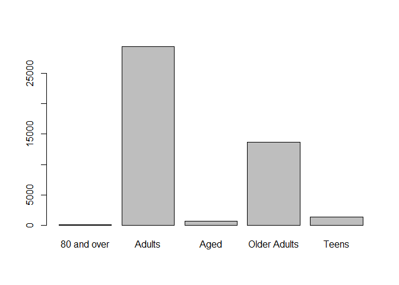

```r
barplot(table(newdata$age_category))
```

**Based on the data, clients with adults category which is between 26y - 45y are the highest.**

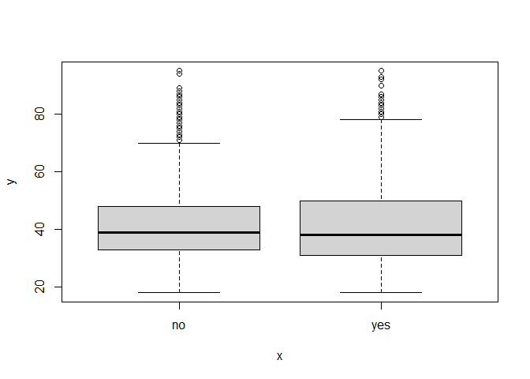

```r
plot(newdata$y, newdata$age)
```

From the box diagram, it can be concluded that the variation of data based on age varies more for clients with subscription categories.

**Now, do subset the data (y = yes). We will process the data only on the client who subscribed a term deposit.**

```r
subscribed_yes <- bank[bank$y == 'yes',]
dim(subscribed_yes)
```

```
## [1] 5289   17
```

*3. What is the average balance of the clients who subscribed a term deposit?*

Let’s check is there any outlier of the data

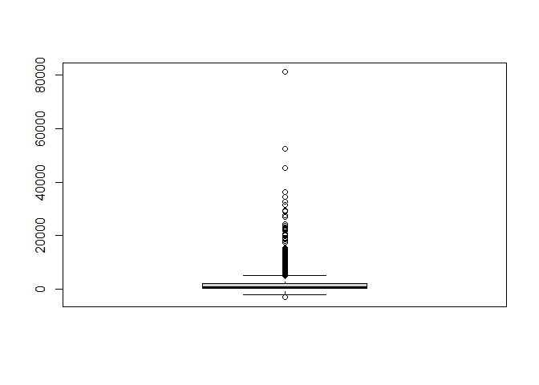

```r
boxplot(subscribed_yes$balance)
```

From the plot, there are outliers. So, we can use the **median** to calculate the mean of balance.

```r
median(subscribed_yes$balance)
```

```
## [1] 733
```

```r
top_age <- aggregate(balance ~ age, data = newdata, FUN = length)
top_age <- top_age[order(top_age$balance, decreasing = TRUE), ]
head(top_age <- top_age[order(top_age$balance, decreasing = TRUE), ], 10)
```

```
##    age balance
## 15  32    2085
## 14  31    1996
## 16  33    1972
## 17  34    1930
## 18  35    1894
## 19  36    1806
## 13  30    1757
## 20  37    1696
## 22  39    1487
## 21  38    1466
```

*5. Which age clients subscribe to the most term deposits?*

```r
subs_age <- aggregate(y ~ age, data = subscribed_yes, FUN = length)
subs_age <- subs_age[order(subs_age$y, decreasing = TRUE), ]
head(subs_age <- subs_age[order(subs_age$y, decreasing = TRUE), ], 10)
```

```
##    age   y
## 15  32 221
## 13  30 217
## 16  33 210
## 18  35 209
## 14  31 206
## 17  34 198
## 19  36 195
## 12  29 171
## 20  37 170
## 11  28 162
```

**Answer: Based on this data, term deposits are mostly used by clients at the age of 32 years. In the top 10 data shows that term deposits are mostly used by clients in their 30s.**

*6. Which marital status is the highest?*

```r
subs_m <- aggregate(y ~ marital, data = subscribed_yes, FUN = length)
subs_m
```

```
##    marital    y
## 1 divorced  622
## 2  married 2755
## 3   single 1912
```

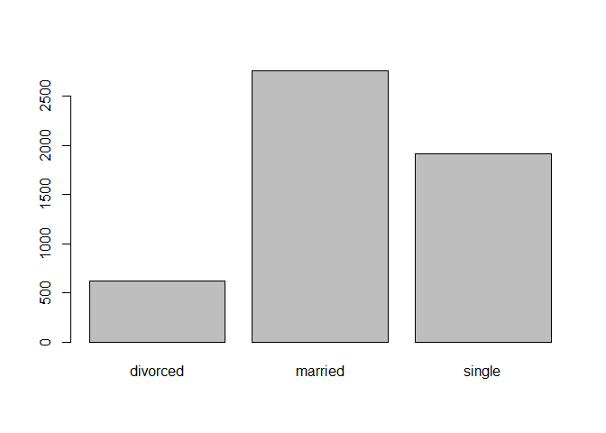

```r
graphics::barplot(table(subscribed_yes$marital))
```

**Answer: married is the highest**

*7. Which jobs that subscribed the most term deposit?*

```r
subs_job <- aggregate(y ~ job, data = subscribed_yes, FUN = length)
subs_job <- subs_job[order(subs_job$y, decreasing = TRUE), ]
subs_job
```

```
##              job    y
## 5     management 1301
## 10    technician  840
## 2    blue-collar  708
## 1         admin.  631
## 6        retired  516
## 8       services  369
## 9        student  269
## 11    unemployed  202
## 7  self-employed  187
## 3   entrepreneur  123
## 4      housemaid  109
## 12       unknown   34
```

**Answer: Top job -> Management**

*8. Which month is the highest subscribed term deposit?*

```r
f <- aggregate(y ~ month , data = subscribed_yes, FUN = length)
f <- f[order(f$y, decreasing = TRUE), ]
f
```

```
##    month   y
## 9    may 925
## 2    aug 688
## 6    jul 627
## 1    apr 577
## 7    jun 546
## 4    feb 441
## 10   nov 403
## 11   oct 323
## 12   sep 269
## 8    mar 248
## 5    jan 142
## 3    dec 100
```

**Answer: Subscribed term deposit is the highest in May**

*9. How correlation between the number of contacts made during the campaign and client subscribed a term deposit in each month?*

First, Created an object for the number of contacts made during the campaign.

```r
e <- aggregate(campaign ~ month , data = subscribed_yes, FUN = sum)
e <- e[order(e$campaign, decreasing = TRUE), ]
e
```

```
##    month campaign
## 9    may     1944
## 2    aug     1849
## 6    jul     1799
## 7    jun     1248
## 1    apr     1037
## 4    feb      884
## 10   nov      687
## 11   oct      491
## 8    mar      470
## 12   sep      454
## 5    jan      251
## 3    dec      210
```

Now, we can find the correlation between the number of contacts made during the campaign and client subscribed a term deposit in each month

```r
cor(e$campaign, f$y)
```

```
## [1] 0.955626
```

**Answer : the correlation is 0.955626 close to 1 (positive correlation), meaning if the value of the campaign goes up, the subscription value of the term deposit goes up, if the value of the campaign down, the subscription value of the term deposit down.**

*10. Based on previous campaign at the same client, is it the number of contacts influence the success of campaign?*

```r
aggregate(previous ~ poutcome, data = subscribed_yes, FUN = sum)
```

```
##   poutcome previous
## 1  failure     1918
## 2    other     1228
## 3  success     3041
## 4  unknown        3
```

```r
aggregate(previous ~ poutcome, data = subscribed_yes, FUN = length)
```

```
##   poutcome previous
## 1  failure      618
## 2    other      307
## 3  success      978
## 4  unknown     3386
```

# 4. Conclussion

Based on campaign data from Portuguese banking institutions, the data consisted of a total of 45211 customers. However, there were only 5,289 customers who subscribed to time deposits based on the campaign.Based on age, most clients are from the adult category with the age range 25 years - 45 years.

In addition, clients in the adult category also subscribed to the most deposits, especially in their 30s. In marital category, married has clients who subscribe to the highest time deposits. This is also related to age, because in the adult category it is very possible for someone to get married.

Thus, the clients in the adult category have a greater chance of subscribing to deposits. So, maybe in the next campaign can be done marketing to more clients in the adult category in order to increase the sales.